# Homework 10

### Extension of Chapter Two

#### Corpus with complex emotions

For our extension, We will use a romance book called “The Story of the Lover” by Hutchins Hapgood. Let’s say for the sentiments, we want to view only the terms that surround negative emotions like anger.

Lets use the nrc lexicon and retrieve the most common words from the book which involves anger. From our pull, We see a plot that could be about another partner as terms like jealously, possession and infidelity ranked in the top ten of the list.

```r
story_lover <- gutenberg_download(67706)
```

```
## Determining mirror for Project Gutenberg from http://www.gutenberg.org/robot/harvest
```

```
## Using mirror http://aleph.gutenberg.org
```

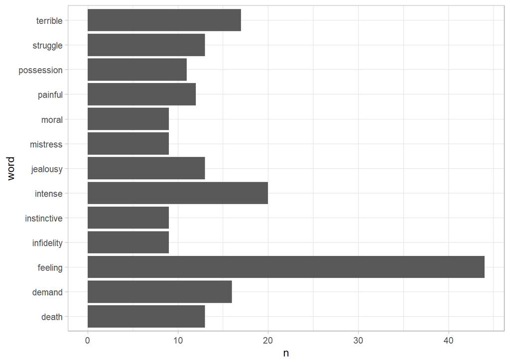

```r
story_lover<-story_lover%>%ungroup() %>%
  unnest_tokens(word, text)

story_lover<-story_lover%>% filter(!(word %in% stopwords(source = "snowball")))

nrc_anger<-get_sentiments("nrc")%>%filter(sentiment=="anger")

story_lover %>%
  inner_join(nrc_anger) %>%
  count(word, sort = TRUE)%>%slice_max(n, n = 10)%>%ggplot(aes(n, word)) +
  geom_col(show.legend = FALSE) +theme_light()
```

#### Expansions of lexicons

For our new lexicon, I will use the lexicon package to retrieve a new lexicon. For our analysis, Lets see the most common terms associated with sensations. I will use the key regressive imagery table to best reflect the term.

Sensations like sight and touch were most used in the novel compared the other three senses.

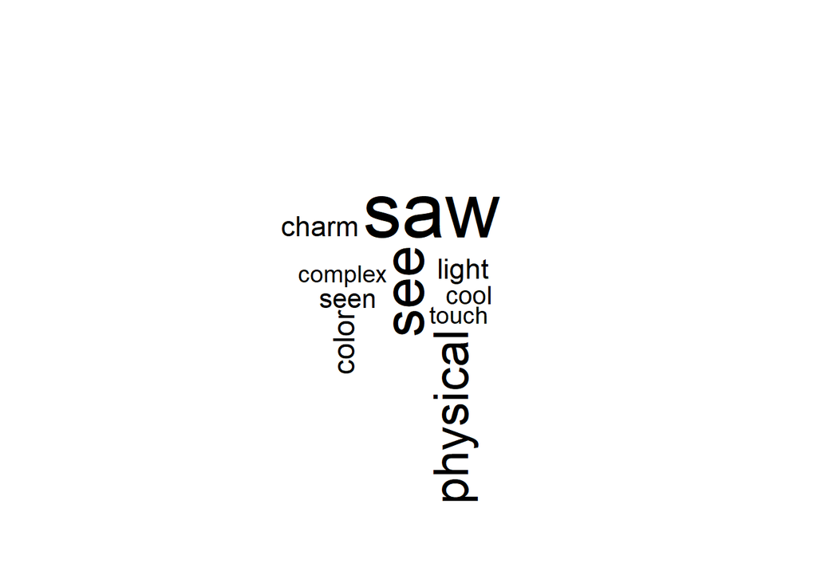

```r
imagery<-key_regressive_imagery
imagery<-imagery%>%filter(category=="sensation")
imagery$regex<-str_replace_all(imagery$regex,"[\\\\b]","")
names(imagery)<-c("x","y","z","a","word")

story_lover %>%
  inner_join(imagery) %>%
  count(word, sort = TRUE)%>%slice_max(n, n = 10)%>%with(wordcloud(word, n, max.words = 100))
```

[^1]: Robinson, Julia Silge and David. “2 Sentiment Analysis with Tidy Data: Text Mining with R.” 2 Sentiment Analysis with Tidy Data | Text Mining with R, https://www.tidytextmining.com/sentiment.html.